# Week3-1

## Week 3-1: Lasso regression

#### Announcement

- HW1 posted
- Group list due this Sunday @ midnight

#### Last time

- Ridge regression

#### Today

- Lasso regression
- LARS

#### References

- ESL, Chapter 3
- James Sharpnack's lecture notes
- Robert Tibshirani (1996). Regression Shrinkage and Selection via the Lasso. *JRSSB* 58:267--288
- Bradley Efron, Trevor Hastie, Iain Johnstone and Robert Tibshirani (2004). Least Angle Regression. *AOS* 32:407--451

### Lasso

[figure not shown]

Lasso, short for 'least absolute selection operator', which shrinks some coefficients and sets others to 0, hence tries to retain the good features of both subset selection and ridge regression.

$$\min_{\beta \in \mathbb{R}^p} \left\{ \|Y - X\beta\|_2^2 + \lambda \|\beta\|_1 \right\},$$

where $\|\beta\| = \sum_{j=1}^p |\beta_j|$

### Why the lasso will often produce coefficients that are exactly 0?

[figure not shown]

From Robert Tibshirani (1996):

Consider $p = 2$

- The elliptic contours are the function $(\beta - \hat\beta)'X'X(\beta - \hat \beta)$, $\hat \beta$ the OLS estimator. The contours are centered at $\hat \beta$.
- The constraint regions are $|\beta_1|+|\beta_2| \leq t$ in (a) and $\beta_1^2 + \beta_2^2 \leq t$ in (b)
- In Fig. 2(a): The lasso solution is the first place that the contours touch the square, and this will sometimes occur at a corner, corresponding to a zero coefficient.
- The picture for ridge regression is shown in Fig. 2(b): there are no corners for the contours to hit and hence zero solutions will rarely result.

### Bias and variance

The bias and variance of lasso regression estimates behave in the same general manner as they did for ridge regression. The bias increases as $\lambda$ (amount of shrinkage) increases, and the variance decreases as $\lambda$ (amount of shrinkage) increases.

(Source: [Ryan Tibshirani's notes](https://www.stat.cmu.edu/~ryantibs/advmethods/notes/highdim.pdf))

### Degrees of freedom

Degrees of freedom is a way of quantifying the effective number of parameters used by a fitting procedure.

#### Linear regression

In usual linear regression setting, the degrees of freedom of a model is the number of free parameters $p$.

#### Ridge regression

In ridge regression, we define the *effective degress of freedom* as $$ df(\lambda) = \text{tr}[X'(X'X + \lambda I_p)^{-1} X'] = \sum_{j=1}^p \frac{d_j^2}{d_j^2 + \lambda}, $$ which is a monotone decreasing function of $\lambda$.

- when $\lambda = 0$, the effective degrees of freedom is $p$;
- when $\lambda \to \infty$, the effective degress of freedom $\to 0$.

#### Lasso regression

In lasso, the degrees of freedom is the number of nonzero components in $\hat\beta_{\text{lasso}}$.

### How to choose $\lambda$?

Most popular approach is to use cross-validation to choose $\lambda$ and then apply the one standard error rule

- Consider a set of values of $\lambda = \{\lambda_1, \dots, \lambda_m\}$
- For each $\lambda$, perform $K$-fold cross validation and compute the prediction error $$ \text{CVErr}(\hat \beta_{\text{lasso}}(\lambda)) = \frac{1}{K} \sum_{k=1}^K \text{PreErr}_k ((\hat \beta_{\text{lasso}})^{-(k)}) $$
- Pick the tunning parameter $\hat \lambda$ from the usual error rule: $$ \hat \lambda = \min_{\lambda \in \{\lambda_1, \dots, \lambda_m\}} \text{CVErr}(\hat \beta_{\text{lasso}}(\lambda)) $$
- We can achieve smaller, simpler models with comparable predictive performance by using *the one standard error rule*:
  1. Compute the cross-validation standard error: $$ \text{SE}(\text{CVErr}(\hat \beta_{\text{lasso}}(\lambda))) = \frac{1}{\sqrt{K}} \text{sd} \left( \text{PreErr}_1 ((\hat \beta_{\text{lasso}})^{-(1)}), \dots, \text{PreErr}_K ((\hat \beta_{\text{lasso}})^{-(K)}) \right) $$
  2. Choose $\hat \lambda_{\text{lasso}}$ such that $$ \hat \lambda_{\text{lasso}} = \max\{\lambda \in \{\lambda_1, \dots, \lambda_m\}, \quad \text{CVErr}(\hat \beta_{\text{lasso}}(\lambda)) \leq \text{CVErr}(\hat \beta_{\text{lasso}}(\hat \lambda)) + \text{SE}(\text{CVErr}(\hat \beta_{\text{lasso}}(\lambda)))\} $$

[figure not shown]

Example: $n$ = 50, $p$ = 30, 10 truly large coefficients, 20 zero coefficients. The one standard error rule chooses a model with 15 variables, whereas the usual rule chooses a model with 20.

### Orthogonal design

Under the orthogonal design $X'X = nI_p$, lasso estimation can be simplified as solving $$ \hat \beta_j = \min_{\beta_j} \left\{ \frac{1}{2} (\hat \beta_j^{OLS} - \beta_j)^2 + \lambda |\beta_j| \right\} $$

Then the lasso estimator is given by $$ \hat \beta_j = S(\hat \beta_j^{OLS}, \lambda), $$ where $S(z, \lambda) = \text{sgn}(z)(|z| - \lambda)_+$, $\text{sgn}(z)$ is the sign of $z$.

It performs the so-called *soft thresholding*

[figure not shown]

### Wavelet denoising

Soft thresholding is commonly used for orthonormal bases.

- Suppose that we have a vector $y_1,\ldots, y_T$ (like a time series).
- And we want to reconstruct $y$ with $W \beta$ where $\beta$ has a small sum of absolute values $\sum_i |\beta_i|$
- $W$ is $T \times T$ and $W W^\top = W^\top W = I$ (orthonormal full rank design)

Want to minimize $$ \frac 12 \sum_{j=1}^T (y - W \beta)_j^2 + \lambda \sum_{j=1}^T |\beta_j|. $$

```python
import numpy as np
import pandas as pd
import matplotlib.pyplot as plt
```

```python
## Explore Turkish stock exchange dataset

tse = pd.read_excel('../data/data_akbilgic.xlsx',skiprows=1)

tse = tse.rename(columns={'ISE':'TLISE','ISE.1':'USDISE'})
```

```python
tse.head
```

```
<bound method NDFrame.head of           date     TLISE    USDISE        SP       DAX      FTSE    NIKKEI  \
0   2009-01-05  0.035754  0.038376 -0.004679  0.002193  0.003894  0.000000
1   2009-01-06  0.025426  0.031813  0.007787  0.008455  0.012866  0.004162
2   2009-01-07 -0.028862 -0.026353 -0.030469 -0.017833 -0.028735  0.017293
3   2009-01-08 -0.062208 -0.084716  0.003391 -0.011726 -0.000466 -0.040061
4   2009-01-09  0.009860  0.009658 -0.021533 -0.019873 -0.012710 -0.004474
..         ...       ...       ...       ...       ...       ...       ...
531 2011-02-16  0.008599  0.013400  0.006238  0.001925  0.007952  0.005717
532 2011-02-17  0.009310  0.015977  0.003071 -0.001186  0.000345  0.002620
533 2011-02-18  0.000191 -0.001653  0.001923  0.002872 -0.000723  0.000568
534 2011-02-21 -0.013069 -0.013706 -0.020742 -0.014239 -0.011275  0.001358
535 2011-02-22 -0.007246 -0.019442  0.000000 -0.000473 -0.002997 -0.017920

      BOVESPA        EU        EM
0    0.031190  0.012698  0.028524
1    0.018920  0.011341  0.008773
2   -0.035899 -0.017073 -0.020015
3    0.028283 -0.005561 -0.019424
4   -0.009764 -0.010989 -0.007802
..        ...       ...       ...
531  0.018371  0.006975  0.003039
532  0.001686 -0.000581  0.001039
533  0.005628  0.000572  0.006938
534 -0.011942 -0.012615 -0.000958
535 -0.012252 -0.005465 -0.014297

[536 rows x 10 columns]>
```

```python
tse.shape # check dimension
```

```
(536, 10)
```

```python
def const_wave(T,a,b):
    wave = np.zeros(T)
    s1 = (b-a) // 2
    s2 = (b-a) - s1
    norm_C = (s1*s2 / (s1+s2))**0.5
    wave[a:a+s1] = norm_C / s1
    wave[a+s1:b] = -norm_C / s2
    return wave
```

```python
def _const_wave_basis(T,a,b):
    if b-a < 2:
        return []
    wave_basis = []
    wave_basis.append(const_wave(T,a,b))
    mid_pt = a + (b-a)//2
    wave_basis += _const_wave_basis(T,a,mid_pt)
    wave_basis += _const_wave_basis(T,mid_pt,b)
    return wave_basis
```

```python
def const_wave_basis(T,a,b):
    father = np.ones(T) / T**0.5
    return [father] + _const_wave_basis(T,a,b)
```

```python
# Construct discrete Haar wavelet basis
T,p = tse.shape
wave_basis = const_wave_basis(T,0,T)
W = np.array(wave_basis).T
```

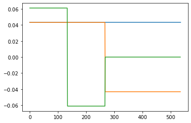

```python
_ = plt.plot(W[:,:3])
```

```python
def soft(y,lamb):
    pos_part = (y - lamb) * (y > lamb)
    neg_part = (y + lamb) * (y < -lamb)
    return pos_part + neg_part
```

```python
## Volatility seems most interesting
## will construct local measure of volatility
## remove rolling window estimate (local centering)
## square the residuals

tse = tse.set_index('date')
tse_trem = tse - tse.rolling("7D").mean()
tse_vol = tse_trem**2.

## Make wavelet transformation and soft threshold

tse_wave = W.T @ tse_vol.values
lamb = .001
tse_soft = soft(tse_wave,lamb)
tse_rec = W @ tse_soft # reconstruct tse
tse_den = tse_vol.copy()
tse_den.iloc[:,:] = tse_rec
```

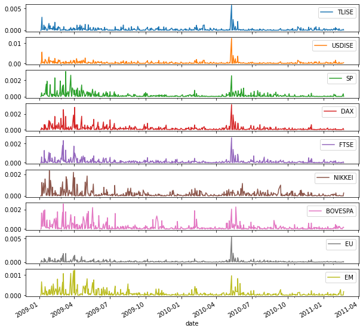

```python
_ = tse_vol.plot(subplots=True,figsize=(10,10))
```

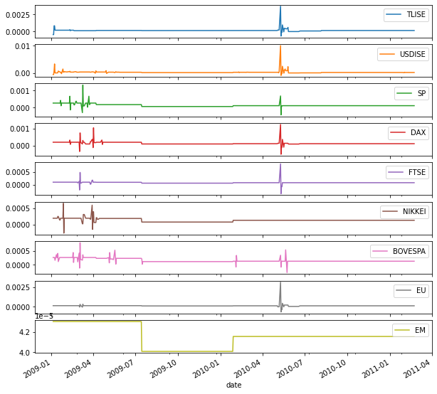

```python
_ = tse_den.plot(subplots=True,figsize=(10,10))
```

### Wavelet reconstruction

Can reconstruct the sequence by $$ \hat y = W \hat \beta. $$ The objective is likelihood term + $\ell_1$ penalty term, $$ \frac 12 \sum_{i=1}^T (y - W \beta)_i^2 + \lambda \sum_{i=1}^T |\beta_i|. $$

> The $\ell_1$ penalty "forces" some $\beta_i = 0$, inducing sparsity

```
[  0   2  48  63 344 345]
```

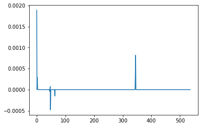

```python
plt.plot(tse_soft[:,4])
high_idx = np.where(np.abs(tse_soft[:,4]) > .0001)[0]
print(high_idx)
```

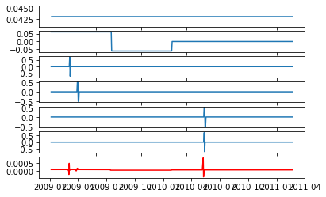

```python
fig, axs = plt.subplots(len(high_idx) + 1,1)
for i, idx in enumerate(high_idx):
    axs[i].plot(W[:,idx])
plt.plot(tse_den['FTSE'],c='r')
```

### Lasso - non-orthogonal design

Recall that the objective is likelihood term + $\ell_1$ penalty term, $$ \frac 12 \|y - X \beta\|^2 + \lambda \|\beta\|_1. $$ does not have closed form for $X$ that is non-orthogonal.

- it is convex
- it is non-smooth (recall $|x|$)
- has tuning parameter $\lambda$

### Solving the Lasso

The lasso can be written in *regularized form*, $$ \min_\beta \frac 12 \|y - X\beta\|^2 + \lambda \sum_{j=1}^p |\beta_j|, $$ or in *constrained form*, $$ \min_\beta \frac 12 \|y - X\beta\|^2, \quad \textrm{s.t.} \sum_{j=1}^p |\beta_j| \le t, $$ for every $\lambda$ there is a $t$ such that the regularized form and constrained form have the same argmin

Algorithms:

```
- Coordinate descent.
- Convex optimization algorithms.
- Least angle regression (LARS). See Efron et al. (2004).
- Others
```

### Least Angle Regression (LAR/LARS)

1. Standardize predictors and start with residual $r = y - \bar y$, $\hat \beta = 0$
2. Find $x_j$ most correlated with $r$
3. Move $\beta_j$ in the direction of $x_j^\top r$ until the residual is more correlated with another $x_k$
4. Move $\beta_j,\beta_k$ in the direction of their joint OLS coefficients of $r$ on $(x_j,x_k)$ until some other competitor $x_l$ has as much correlation with the current residual
5. Continue until all predictors have been entered.

### Understanding LAR

Recall that we've learned forward stepwise regression. To add one variable at a time. At each step, identify the best variable to include in the model, and then update the least square fit sequentially.

LAR uses a similar idead but instead of exploiting the current variable at much as possible, LARS only fits the current variable to a certain level.

At first step, similar to the forward stepwise regression, identify the variable most correlated with the response.

Then, increase the coefficient for this variable:

- What happens here is that the correlation between this variable and the residual of the fit to decrease (as the coefficient slowly increases)
- stop until another variable has the same absolute correlation (with the residual) as the current one. At this point, both variables are in the active set.

- Note that the variable which just entered the active set had coefficient 0.
- The correlations between the variables in $\mathcal{S}$ and the residual $r(\alpha) = y − X_\mathcal{S} \beta_{\mathcal{S}}(\alpha)$ decrease at the same time as $\alpha$ increases

Increase $\alpha$, until there is another variable which has as much correlation with the residual $r(\alpha)$ as the ones in the active set $\mathcal{S}$, at which point, the new variable enters the active set and the iterations restart.

- At each iteration, there is a value for $\beta$. This corresponds to a value of $t = \|\beta\|_1$
- At the very beginning, when there was no variable in the active set. One could consider $t = 0$, i.e., $\|\beta\|_1 = 0$ or $\lambda = \infty$
- In the end, when all variables are in the active set. This corresponds to $t = \|\hat \beta^{OLS}\|_1$, i.e., $\lambda = 0$.

Further reading: https://b-thi.github.io/pdfs/LARS.pdf

[figure not shown]

### LARS with lasso modification

4.5 If a non-zero coefficient drops to 0 then remove it from the active set and recompute the restricted OLS.

[figure not shown]

from ESL

```python
# %load ../standard_import.txt
import pandas as pd
import numpy as np
import matplotlib.pyplot as plt
from sklearn import preprocessing, model_selection, linear_model

%matplotlib inline
```

```python
## Simulate a dataset for lasso
np.random.seed(2022)
n=100
p=1000
X = np.random.randn(n,p)
X = preprocessing.scale(X)
```

```python
## Subselect true active set
sprob = 0.02
Sbool = np.random.rand(p) < sprob
s = np.sum(Sbool)
print("Number of non-zero's: {}".format(s))
```

```
Number of non-zero's: 17
```

```python
## Construct beta and y

mu = 100.
beta = np.zeros(p)
beta[Sbool] = mu * np.random.randn(s)

eps = np.random.randn(n)
y = X.dot(beta) + eps
```

Run the lasso using `linear_model.lars_path` with the lasso modification (see docstring with ?linear_model.lars_path)

Plot the lasso coefficients that are learned as a function of lambda. You should have a plot with the x-axis being lambda and the y-axis being the coefficient value, with $p=1000$ lines plotted. Highlight the $s$ coefficients that are truly non-zero by plotting them in red.

```python
?linear_model.lars_path
```

```python
## Answer to exercise 5.3
## Run lars with lasso mod, find active set

larper = linear_model.lars_path(X,y,method="lasso")
S = set(np.where(Sbool)[0])

def plot_it():
    for j in S:
        _ = plt.plot(larper[0],larper[2][j,:],'r')
    for j in set(range(p)) - S:
        _ = plt.plot(larper[0],larper[2][j,:],'k',linewidth=.75)
    _ = plt.title('Lasso path for simulated data')
    _ = plt.xlabel('lambda')
    _ = plt.ylabel('Coef')
```

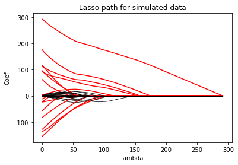

```python
plot_it()
```

```python
## Hitters dataset

df = pd.read_csv('../data/Hitters.csv', index_col=0).dropna()
df.index.name = 'Player'
df.info()
```

```
<class 'pandas.core.frame.DataFrame'>
Index: 263 entries, -Alan Ashby to -Willie Wilson
Data columns (total 20 columns):
 #   Column     Non-Null Count  Dtype
---  ------     --------------  -----
 0   AtBat      263 non-null    int64
 1   Hits       263 non-null    int64
 2   HmRun      263 non-null    int64
 3   Runs       263 non-null    int64
 4   RBI        263 non-null    int64
 5   Walks      263 non-null    int64
 6   Years      263 non-null    int64
 7   CAtBat     263 non-null    int64
 8   CHits      263 non-null    int64
 9   CHmRun     263 non-null    int64
 10  CRuns      263 non-null    int64
 11  CRBI       263 non-null    int64
 12  CWalks     263 non-null    int64
 13  League     263 non-null    object
 14  Division   263 non-null    object
 15  PutOuts    263 non-null    int64
 16  Assists    263 non-null    int64
 17  Errors     263 non-null    int64
 18  Salary     263 non-null    float64
 19  NewLeague  263 non-null    object
dtypes: float64(1), int64(16), object(3)
memory usage: 43.1+ KB
```

```python
df.head()
```

| Player | AtBat | Hits | HmRun | Runs | RBI | Walks | Years | CAtBat | CHits | CHmRun | CRuns | CRBI | CWalks | League | Division | PutOuts | Assists | Errors | Salary | NewLeague |
| --- | --- | --- | --- | --- | --- | --- | --- | --- | --- | --- | --- | --- | --- | --- | --- | --- | --- | --- | --- | --- |
| -Alan Ashby | 315 | 81 | 7 | 24 | 38 | 39 | 14 | 3449 | 835 | 69 | 321 | 414 | 375 | N | W | 632 | 43 | 10 | 475.0 | N |
| -Alvin Davis | 479 | 130 | 18 | 66 | 72 | 76 | 3 | 1624 | 457 | 63 | 224 | 266 | 263 | A | W | 880 | 82 | 14 | 480.0 | A |
| -Andre Dawson | 496 | 141 | 20 | 65 | 78 | 37 | 11 | 5628 | 1575 | 225 | 828 | 838 | 354 | N | E | 200 | 11 | 3 | 500.0 | N |
| -Andres Galarraga | 321 | 87 | 10 | 39 | 42 | 30 | 2 | 396 | 101 | 12 | 48 | 46 | 33 | N | E | 805 | 40 | 4 | 91.5 | N |
| -Alfredo Griffin | 594 | 169 | 4 | 74 | 51 | 35 | 11 | 4408 | 1133 | 19 | 501 | 336 | 194 | A | W | 282 | 421 | 25 | 750.0 | A |

```python
dummies = pd.get_dummies(df[['League', 'Division', 'NewLeague']])
dummies.info()
print(dummies.head())
```

```
<class 'pandas.core.frame.DataFrame'>
Index: 263 entries, -Alan Ashby to -Willie Wilson
Data columns (total 6 columns):
 #   Column       Non-Null Count  Dtype
---  ------       --------------  -----
 0   League_A     263 non-null    uint8
 1   League_N     263 non-null    uint8
 2   Division_E   263 non-null    uint8
 3   Division_W   263 non-null    uint8
 4   NewLeague_A  263 non-null    uint8
 5   NewLeague_N  263 non-null    uint8
dtypes: uint8(6)
memory usage: 3.6+ KB
                   League_A  League_N  Division_E  Division_W  NewLeague_A  \
Player
-Alan Ashby               0         1           0           1            0
-Alvin Davis              1         0           0           1            1
-Andre Dawson             0         1           1           0            0
-Andres Galarraga         0         1           1           0            0
-Alfredo Griffin          1         0           0           1            1

                   NewLeague_N
Player
-Alan Ashby                  1
-Alvin Davis                 0
-Andre Dawson                1
-Andres Galarraga            1
-Alfredo Griffin             0
```

```python
y = df.Salary

# Drop the column with the independent variable (Salary), and columns for which we created dummy variables
X_ = df.drop(['Salary', 'League', 'Division', 'NewLeague'], axis=1).astype('float64')
# Define the feature set X.
X = pd.concat([X_, dummies[['League_N', 'Division_W', 'NewLeague_N']]], axis=1)
X.info()
```

```
<class 'pandas.core.frame.DataFrame'>
Index: 263 entries, -Alan Ashby to -Willie Wilson
Data columns (total 19 columns):
 #   Column       Non-Null Count  Dtype
---  ------       --------------  -----
 0   AtBat        263 non-null    float64
 1   Hits         263 non-null    float64
 2   HmRun        263 non-null    float64
 3   Runs         263 non-null    float64
 4   RBI          263 non-null    float64
 5   Walks        263 non-null    float64
 6   Years        263 non-null    float64
 7   CAtBat       263 non-null    float64
 8   CHits        263 non-null    float64
 9   CHmRun       263 non-null    float64
 10  CRuns        263 non-null    float64
 11  CRBI         263 non-null    float64
 12  CWalks       263 non-null    float64
 13  PutOuts      263 non-null    float64
 14  Assists      263 non-null    float64
 15  Errors       263 non-null    float64
 16  League_N     263 non-null    uint8
 17  Division_W   263 non-null    uint8
 18  NewLeague_N  263 non-null    uint8
dtypes: float64(16), uint8(3)
memory usage: 35.7+ KB
```

```python
X.head(5)
```

| Player | AtBat | Hits | HmRun | Runs | RBI | Walks | Years | CAtBat | CHits | CHmRun | CRuns | CRBI | CWalks | PutOuts | Assists | Errors | League_N | Division_W | NewLeague_N |
| --- | --- | --- | --- | --- | --- | --- | --- | --- | --- | --- | --- | --- | --- | --- | --- | --- | --- | --- | --- |
| -Alan Ashby | 315.0 | 81.0 | 7.0 | 24.0 | 38.0 | 39.0 | 14.0 | 3449.0 | 835.0 | 69.0 | 321.0 | 414.0 | 375.0 | 632.0 | 43.0 | 10.0 | 1 | 1 | 1 |
| -Alvin Davis | 479.0 | 130.0 | 18.0 | 66.0 | 72.0 | 76.0 | 3.0 | 1624.0 | 457.0 | 63.0 | 224.0 | 266.0 | 263.0 | 880.0 | 82.0 | 14.0 | 0 | 1 | 0 |
| -Andre Dawson | 496.0 | 141.0 | 20.0 | 65.0 | 78.0 | 37.0 | 11.0 | 5628.0 | 1575.0 | 225.0 | 828.0 | 838.0 | 354.0 | 200.0 | 11.0 | 3.0 | 1 | 0 | 1 |
| -Andres Galarraga | 321.0 | 87.0 | 10.0 | 39.0 | 42.0 | 30.0 | 2.0 | 396.0 | 101.0 | 12.0 | 48.0 | 46.0 | 33.0 | 805.0 | 40.0 | 4.0 | 1 | 0 | 1 |
| -Alfredo Griffin | 594.0 | 169.0 | 4.0 | 74.0 | 51.0 | 35.0 | 11.0 | 4408.0 | 1133.0 | 19.0 | 501.0 | 336.0 | 194.0 | 282.0 | 421.0 | 25.0 | 0 | 1 | 0 |

Use cross-validate to select the lambda just like any other tuning parameter.

- Sklearn gives you the option of using their fast cross-validation script via `linear_model.LassoCV`, see the documentation. You can create a leave-one-out cross validator with `model_selection.LeaveOneOut` then pass this to `LassoCV` with the `cv` argument. Do this, and see what the returned fit and selected lambda are.

```python
## Fit the lasso and cross-validate, increased max_iter to achieve convergence
loo = model_selection.LeaveOneOut()
looiter = loo.split(X)
hitlasso = linear_model.LassoCV(cv=looiter,max_iter=2000)
hitlasso.fit(X,y)
```

```
LassoCV(cv=<generator object BaseCrossValidator.split at 0x7fdc1271a0b0>,
        max_iter=2000)
```

```python
print("The selected lambda value is {:.2f}".format(hitlasso.alpha_))
```

```
The selected lambda value is 540.66
```

```python
hitlasso.coef_
```

```
array([-0.        ,  1.49581634,  0.        ,  0.        ,  0.        ,
        1.13968178, -0.        , -0.33741746,  0.82331967,  0.        ,
        0.79940936,  0.65462067, -0.03322761,  0.27574744,  0.13169212,
       -0.        ,  0.        , -0.        ,  0.        ])
```

We can also compare this to the selected model from forward stagewise regression:

```
[-0.21830515,  0.38154135,  0.        ,  0.        ,  0.        ,
        0.16139123,  0.        ,  0.        ,  0.        ,  0.        ,
        0.09994524,  0.56696569, -0.16872682,  0.16924078,  0.        ,
        0.        ,  0.        , -0.19429699,  0.        ]
```

```python
bforw = [-0.21830515,  0.38154135,  0.        ,  0.        ,  0.        ,
        0.16139123,  0.        ,  0.        ,  0.        ,  0.        ,
        0.09994524,  0.56696569, -0.16872682,  0.16924078,  0.        ,
        0.        ,  0.        , -0.19429699,  0.        ]
```

```python
print(", ".join(X.columns[(hitlasso.coef_ != 0.) != (bforw != 0.)]))
```

```
AtBat, HmRun, Runs, RBI, Years, CHmRun, Errors, League_N, Division_W, NewLeague_N
```